# Discussion4-Solution: Stat 371

# Problem 2.

Weights (X) of male cats of a certain breed (A) are well approximated by a normal distribution with mean 4.1 kg and standard deviation of 0.6 kg. That is, $X~\sim N(4.1, 0.6^2)$.

```r
library(ggplot2)
```

**mean = 2, variance = 4**

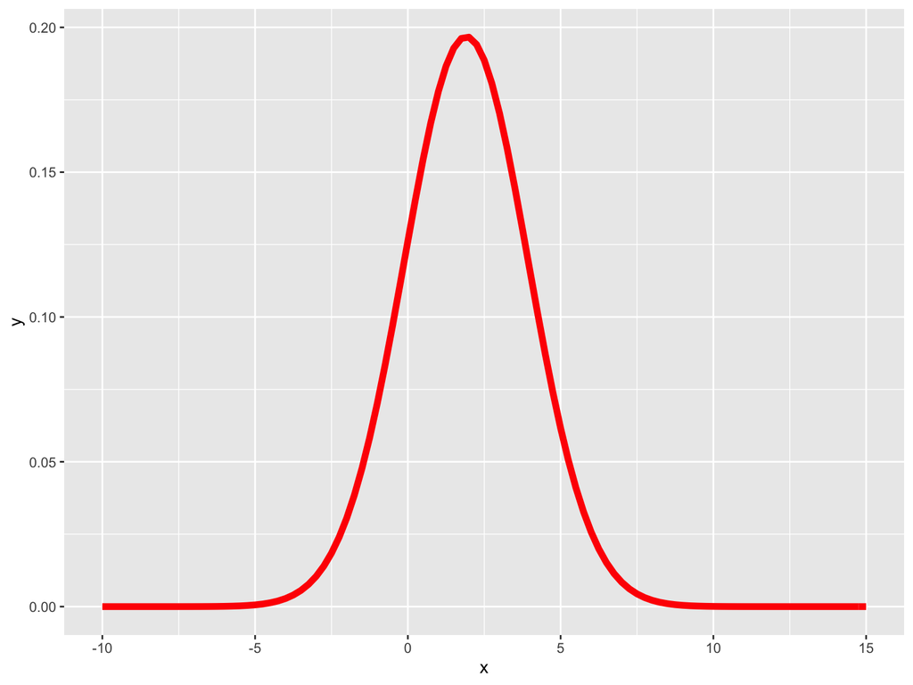

**mean = 2, variance = 25**

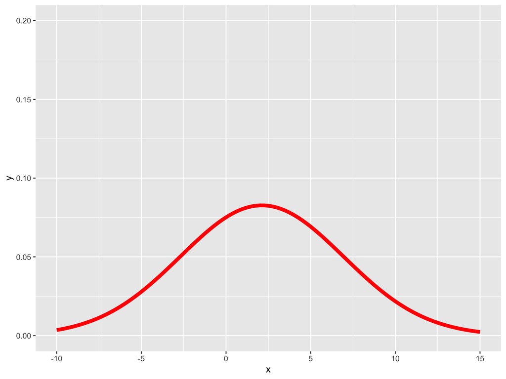

A. What proportion of male cats of that breed (A) have weights between 3.7 and 4.4 kg?

[figure not shown]

[figure not shown]

`Solution:`

```r
#P(3.7<X<4.4)=
(pnorm(q=4.4, mean=4.1, sd=.6)-pnorm(q=3.7, mean=4.1, sd=.6))
```

```
## [1] 0.4389699
```

```r
?pnorm
```

B. A male cat of that breed (A) has a weight that is 0.5 standard deviations above the mean. What percentage of male cats of that breed (A) are heavier than this one?

`Solution:`

```r
(x=4.1+0.5*(0.6))
```

```
## [1] 4.4
```

```r
1-pnorm(q=x,mean=4.1, sd=.6)
```

```
## [1] 0.3085375
```

- The $30.9\%$ of male cats of that breed (A) are heavier that this male cat.

C. How heavy is a male cat of that breed (A) whose weight is at the 80th percentile?

`Solution:`

```r
(qnorm(p=.8, mean=4.1, sd=.6))
```

```
## [1] 4.604973
```

The male cat weight 4.604973

D. `Ten` male cats are chosen at random from that breed (A) (assume there are many of these types of cats). What is the probability that `exactly 2` of them weigh more than 4.5 kg?

- Assume that the weights of the 10 cats are independent since the population is very large. (Sampling such a small number of cats without replacement will not functionally change the probability of the outcome of subsequent cats.)

`Hint:` consider the variable X of interest. An set the value of the parameters.

`Solution:`

- Let X= weight of the male cats. $X~\sim N(mean=4.1,sd=.6)$.
- p=P(X>4.5)

```r
(p=1-pnorm(q=4.5,mean=4.1,sd=0.6))
```

```
## [1] 0.2524925
```

- Le Y= number of males cats that weigh more than 4.5. $Y~\sim Binomial(n=10,p=P(X>4.5))$. That is, $Y~\sim Binomial(n=10,p=0.2524925)$.
- Compute the probability

```r
dbinom(x=2,size=10,p=p)
```

```
## [1] 0.2796623
```

E. Ten male cats are chosen at random from that breed (A) (assume there are many of these types of cats). What is the probability that `the average weight` is between 3.7 and 4.4 kg?

`Solution:`

- We need to consider the distribution of the average weight $\bar{X}$. It has a Normal distribution since it is the linear combination of normal random variables.
- $E(\bar{X})=E(\frac{X_1+X_2+...+X_{10}}{10})=\frac{10*E(X)}{10}=E(X)=\mu$

and

- $\sigma^2_{\bar{X}}=Var(\frac{X_1+X_2+...+X_{10}}{10})=\frac{Var(X_1+X_2+...+X_{10})}{10^2}=\frac{10*Var(X)}{10^2}=\frac{Var(X)}{10}=\frac{.6^2}{10}$ $\sim N(4.1,\frac{.6^2}{10})$ so $P(3.7<\bar{X}<4.4)$ is

```r
pnorm(4.4, 4.1, .6/sqrt(10))-pnorm(3.7, 4.1, .6/sqrt(10))
```

```
## [1] 0.9255694
```

F. The weight of male cats from a different `species (B)` is also normally distributed but we have those weights in pounds (lbs): $Y\sim N(8.65, 1.4^2)$.

- 1kg $\approx$ 2.205 lbs, or 1 lb $\approx$ 0.454 kg.

Compare the weights of the male cats from the two breeds. That is, Male cats from which breed (A) or (B) are heavier[lighter] on average? Which have more[less] variable weight?

`Hint:` In order to compare both breeds, consider the variable Z be the weight of `A cats` in lbs. The compute the expected value and the variance.

`Solution:`

- Let Z be the weight of A cats in lbs.
- $Z=2.205*X$, $E(Z)=2.205*E(X)=2.205*4.1=9.0405$ lbs
- and $Var(Z)=Var(2.205*X)=2.205^2*Var(X)=2.205^2*.6^2$
- so $SD(Z)=2.205\times0.6=1.323\;\textrm{lbs}$.
- Comparing weights in the units of lbs:

B:$Y~N(8.65, 1.4^2)$ A: $P~N(9.04,1.32^2)$. So the A breed is heavier on average and has a lower variability of weight.

# Problem 3

A. Using the dataset lbw and the variable low. Check if the conditions for a binomial random process are satisfied in the sample. Based on your findings, Do you think that it is reasonable to model this data with a Binomial probabilistic model?.

`Solution`

- Read the lbw data set.

```r
lbw<-read.csv2("lbw.csv",sep=",", dec = ".")
lbw$low<-as.factor(lbw$low)
lbw$smoke<-as.factor(lbw$smoke)
lbw$race<-as.factor(lbw$race)
lbw$ht<-as.factor(lbw$ht)
lbw$ui<-as.factor(lbw$ui)
```

- Check the conditions for a binomial random process
1. The random process consists of selecting $n=189$ babies and observe if the baby has low or normal weigh.
2. Each observation of the baby’s weigh results in one of two possible outcomes:
   - `success`= Low weigh (1)
   - `failure`= normal weigh (0).
3. The empirical probability of success on any single trial is the same for every trial, and we can estimate it by $59/189$ or 0.3121693.
4. The observations are `independent` meaning that the outcome of any baby doesn’t affect the probabilities of the outcome in another baby.
5. The variable associated with the random process count the number of babies with low weigh in a fixed sample of size n=189. X theoretically can take values: $0,1,2,\ldots,189$. Here we have only one possible observation of X, x=59.

```r
summary(lbw$low)
```

```
##   0   1
## 130  59
```

- `Conclusion:` From the above checking, we can think that it is reasonable to model this data with a Binomial probabilistic model.

B. Using the dataset lbw and the variable bwt. Check the characteristics of random normal variable in the sample. Based on your findings, Do you think that it is reasonable to model this data with a Normal probabilistic model?.

`Solution`

- Check some characteristic of a Normal random variable
1. The histogram of the data is symmetric

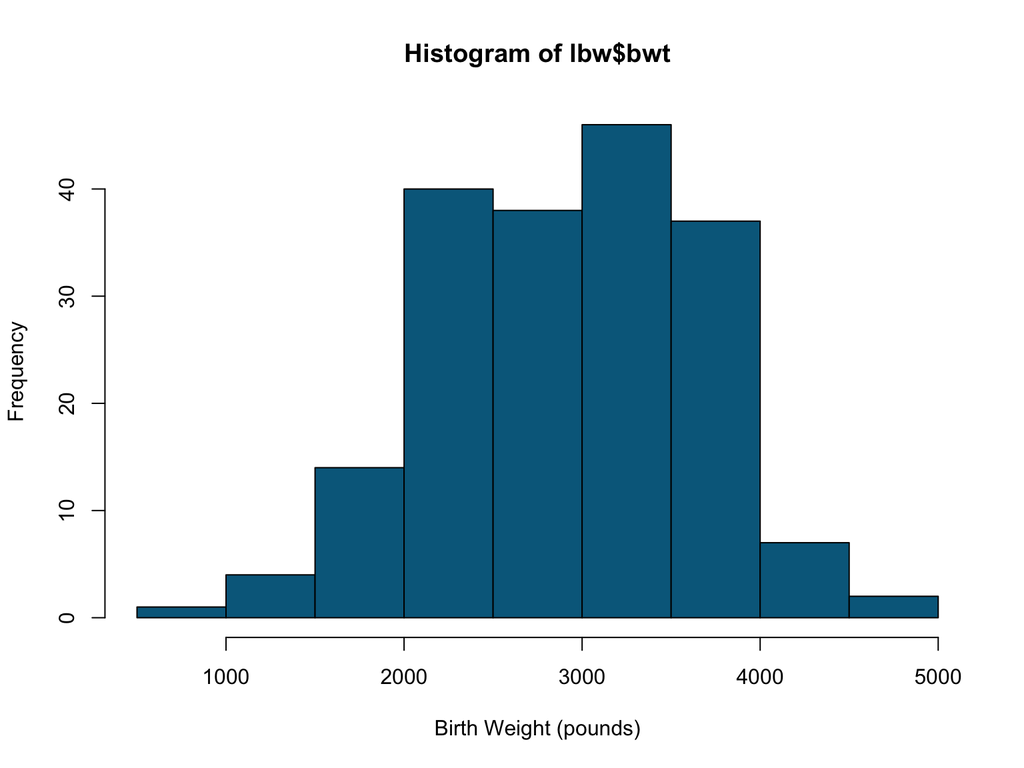

```r
hist(lbw$bwt,col="deepskyblue4",xlab = "Birth Weight (pounds)")
```

The histogram of the sample data is approximately symmetric.

2. The mean, mode, and median are equal

Use the summary function to find the mean and median.

```r
summary(lbw$bwt)
```

```
##    Min. 1st Qu.  Median    Mean 3rd Qu.    Max.
##     709    2414    2977    2944    3475    4990
```

Using the function `table()` and observing the frequency of the values. We found that there are 4 modes: 2495 2920 2977 3651

```r
table(lbw$bwt)
```

```
##
##  709 1021 1135 1330 1474 1588 1701 1729 1790 1818 1885 1893 1899 1928 1936 1970
##    1    1    1    1    1    2    1    1    1    1    1    1    1    3    1    1
## 2055 2082 2084 2100 2125 2126 2187 2211 2225 2240 2282 2296 2301 2325 2353 2367
##    2    1    2    1    1    1    2    1    1    2    1    2    1    1    2    1
## 2381 2395 2410 2414 2424 2438 2442 2450 2466 2495 2523 2551 2557 2594 2600 2622
##    3    1    2    1    1    1    1    1    3    4    1    1    1    1    1    1
## 2637 2663 2665 2722 2733 2750 2769 2778 2782 2807 2821 2835 2836 2863 2877 2906
##    2    1    1    1    1    2    2    1    1    1    1    2    1    1    2    1
## 2920 2922 2948 2977 3005 3033 3042 3062 3076 3080 3090 3100 3104 3132 3147 3175
##    4    1    2    4    1    1    1    3    2    1    3    1    1    1    1    2
## 3203 3225 3232 3234 3260 3274 3303 3317 3321 3331 3374 3402 3416 3430 3444 3459
##    3    2    2    1    1    2    1    3    1    1    2    1    1    1    1    1
## 3460 3473 3475 3487 3544 3572 3586 3600 3614 3629 3637 3643 3651 3699 3728 3756
##    1    1    1    1    1    2    1    1    2    2    1    1    4    1    1    1
## 3770 3790 3799 3827 3856 3860 3884 3912 3940 3941 3969 3983 3997 4054 4111 4153
##    3    1    1    1    1    2    2    1    1    2    1    1    2    2    1    1
## 4167 4174 4238 4593 4990
##    1    1    1    1    1
```

The mean, median, and mode are “close” each other:

```
    - Mode: 2495,  2920,  2977,  3651
    - Mean: 2944
    - Median: 2977
```

4. The interquartile range is 4/3 of the standard deviation.

```r
IQR(lbw$bwt)
```

```
## [1] 1061
```

```r
4/3*sd(lbw$bwt)
```

```
## [1] 972.0214
```

The interquartile range,1061, is “close” to 4/3 of the standard deviation, 972.0214.

5. Th kurtosis is zero

```r
x = lbw$bwt
m = mean(x)
s = sd(x)
n  = length(x)

kurt = sum((x-m)^4/s^4)/n-3
kurt
```

```
## [1] -0.1416673
```

The kurtosis is a “close” to zero.

6. The skewness is zero.

```r
x = lbw$bwt
m = mean(x)
s = sd(x)
n  = length(x)
skew = sum((x-m)^3/s^3)/n
skew
```

```
## [1] -0.2053377
```

The skewness is “close” to zero.

7. The qqplot fit a straight line

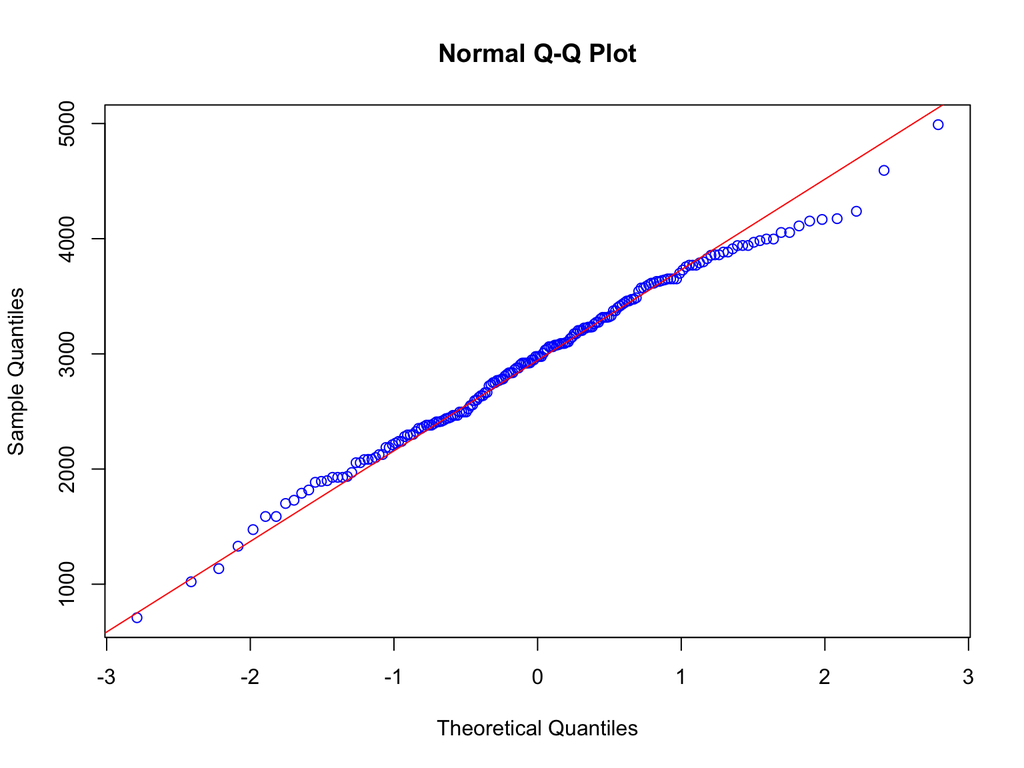

```r
qqnorm(lbw$bwt,col="blue")
qqline(lbw$bwt,col="red")
```

We observe that the qqplot fit well to a straight line

```
    + The authors state: "Normality test for the birth weight data was accomplished through graphically"

    + Do you think that there is something  missing?
```